# Final assignement

Mikael Jumppanen

# Introduction

Aim of the data analysis study is to analalyze student alohol consumption study again. And try to get general view of the data by using MCA, which reveals which factors group together. Primary aim is to determine which factors affect final grades of the student by using linear regression for uncategorized grade variable and LDA for categorized grade variable. I decided to keep dataset separete because I hypothesized that there is difference between those who perform well in math and portuguese.

# Dataset

Dataset consist of two questionaries made for portuguese students who were studying either math or portuguese. During the dataset preparation I scaled all the numerical variables and created new categorical variables: math_grade and por_grade.

# Visual exploration of the datasets

I hypothise that generally women would perform better in language and men in maths. Let’s see that is really the case. It would be also interesting to see if there are some other differences between the data sets.

**Mathematics data**

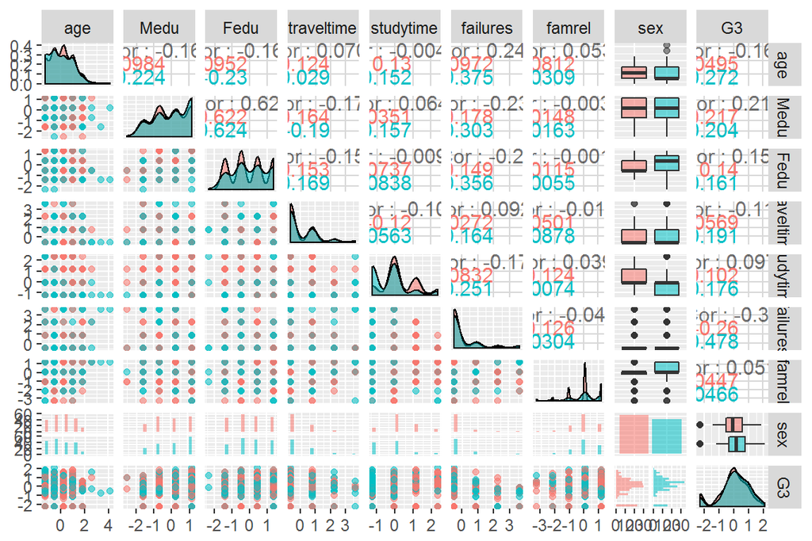

```r
library("GGally")
library("ggplot2")
library("dplyr")
mathData <-read.csv("math_data.csv")
porData <- read.csv("por_data.csv")


select_these_part1 <- c("age","Medu", "Fedu", "traveltime", "studytime", "failures", "famrel", "sex", "G3")

select_these_part2 <- c("freetime", "goout", "health", "absences", "G3", "sex", "alc_use")

numericMath1 <- mathData %>% select(one_of(select_these_part1))

numericMath2 <- mathData %>% select(one_of(select_these_part2))

ggpairs(numericMath1, mapping = aes(col=sex, alpha=0.3), lower = list(combo = wrap("facethist", bins = 20)))
```

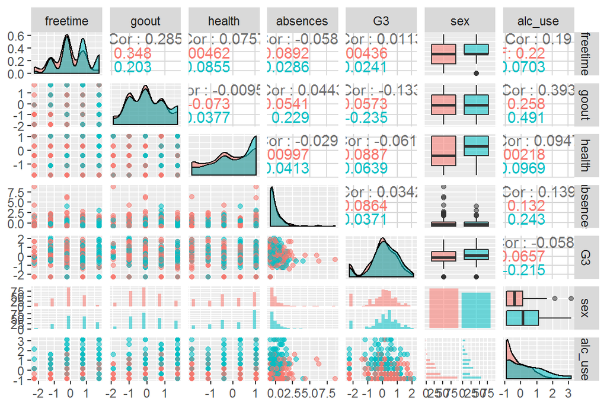

```r
ggpairs(numericMath2, mapping = aes(col=sex, alpha=0.3), lower = list(combo = wrap("facethist", bins = 20)))
```

It seems that men grade’s are more succestible to external factors like going out and drinking of alchol. Interestingly parent’s education seem to affect quite a lot to mathematics grade. Even more that time spent for studying. It seems also that men that have past failures tend to get easier worse grade than women.

**Portuguese data**

```r
glimpse(porData)
```

```
## Observations: 649
## Variables: 36
## $ school     <fctr> GP, GP, GP, GP, GP, GP, GP, GP, GP, GP, GP, GP, GP...
## $ sex        <fctr> F, F, F, F, F, M, M, F, M, M, F, F, M, M, M, F, F,...
## $ age        <dbl> 1.0309000, 0.2099747, -1.4318759, -1.4318759, -0.61...
## $ address    <fctr> U, U, U, U, U, U, U, U, U, U, U, U, U, U, U, U, U,...
## $ famsize    <fctr> GT3, GT3, LE3, GT3, GT3, LE3, LE3, GT3, LE3, GT3, ...
## $ Pstatus    <fctr> A, T, T, T, T, T, T, A, A, T, T, T, T, T, A, T, T,...
## $ Medu       <dbl> 1.3092058, -1.3350097, -1.3350097, 1.3092058, 0.427...
## $ Fedu       <dbl> 1.539528, -1.187916, -1.187916, -0.278768, 0.630380...
## $ Mjob       <fctr> at_home, at_home, at_home, health, other, services...
## $ Fjob       <fctr> teacher, other, other, services, other, other, oth...
## $ reason     <fctr> course, course, other, home, home, reputation, hom...
## $ guardian   <fctr> mother, father, mother, mother, father, mother, mo...
## $ traveltime <dbl> 0.5762735, -0.7594462, -0.7594462, -0.7594462, -0.7...
```

[output cut: 23 more lines]

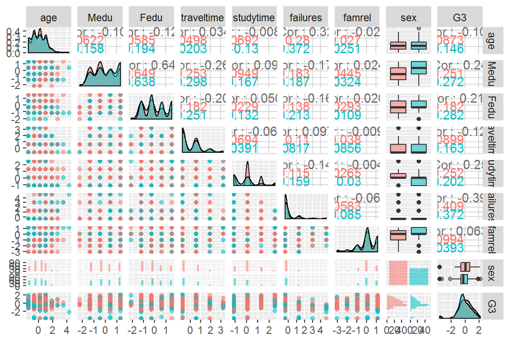

```r
select_these_part1 <- c("age","Medu", "Fedu", "traveltime", "studytime", "failures", "famrel", "sex", "G3")

select_these_part2 <- c("freetime", "goout", "health", "absences", "G3", "sex", "alc_use")

numericMath1 <- porData %>% select(one_of(select_these_part1))

numericMath2 <- porData %>% select(one_of(select_these_part2))

ggpairs(numericMath1, mapping = aes(col=sex, alpha=0.3), lower = list(combo = wrap("facethist", bins = 20)))
```

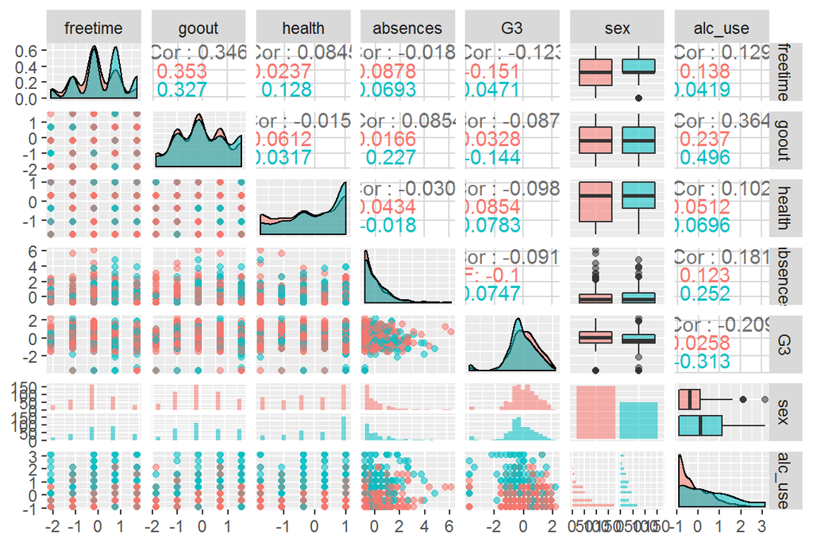

```r
ggpairs(numericMath2, mapping = aes(col=sex, alpha=0.3), lower = list(combo = wrap("facethist", bins = 20)))
```

It seem that for studying portuguese parents education affect even more than for studying maths. Interestingly there seem to be stronger correlation in time spent for studying vs. grade in portuguese.

# Data analysis

Let’s first make MCA based on **Father’s job**, **famsup**, **internet**, **romantic** and **por_grade** variables

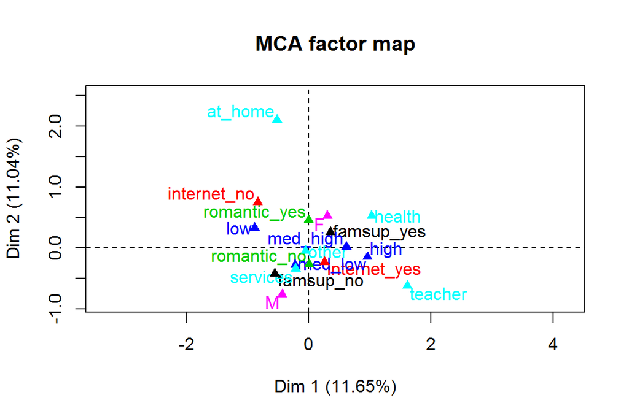

```r
library("FactoMineR")



select_these <- c("F", "famsup", "internet", "romantic", "por_grade", "Fjob", "sex")

porFactor <- porData %>% select_if(is.factor) %>% select(one_of(select_these))
mca <- MCA(porFactor, graph = F)

# visualize MCA
plot(mca, invisible=c("ind"), habillage="quali")
```

It seems that having internet and teacher dad or on health sector would help to get better grades. Family support might also differentiate med_low grade from med_high

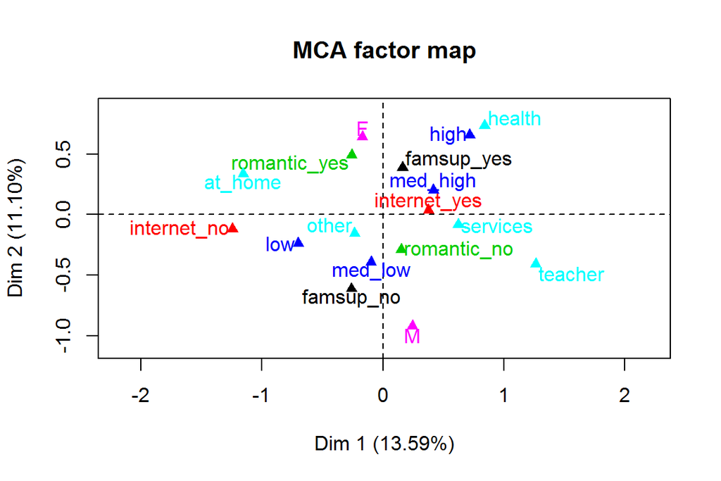

```r
library("FactoMineR")



select_these <- c("F", "famsup", "internet", "romantic", "por_grade", "Mjob", "sex")

porFactor <- porData %>% select_if(is.factor) %>% select(one_of(select_these))
mca <- MCA(porFactor, graph = F)

# visualize MCA
plot(mca, invisible=c("ind"), habillage="quali")
```

Next we try to fit linear regression model to predict final grade variable(**G3**)

**Portuguese data**

```r
my_model <- lm(formula = G3 ~ alc_use + absences + goout + Medu + Fedu + failures + studytime, data= porData)

summary(my_model)
```

```
##
## Call:
## lm(formula = G3 ~ alc_use + absences + goout + Medu + Fedu +
##     failures + studytime, data = porData)
##
## Residuals:
##     Min      1Q  Median      3Q     Max
## -4.1036 -0.4676  0.0044  0.5250  2.0171
##
## Coefficients:
##               Estimate Std. Error t value Pr(>|t|)
## (Intercept)  1.118e-16  3.438e-02   0.000 1.000000
## alc_use     -1.378e-01  3.809e-02  -3.618 0.000321 ***
## absences    -8.587e-03  3.533e-02  -0.243 0.808051
## goout       -1.367e-02  3.697e-02  -0.370 0.711747
## Medu         1.159e-01  4.546e-02   2.550 0.011015 *
## Fedu         7.959e-02  4.539e-02   1.753 0.080017 .
## failures    -3.212e-01  3.565e-02  -9.011  < 2e-16 ***
## studytime    1.572e-01  3.564e-02   4.412  1.2e-05 ***
## ---
## Signif. codes:  0 '***' 0.001 '**' 0.01 '*' 0.05 '.' 0.1 ' ' 1
##
## Residual standard error: 0.8759 on 641 degrees of freedom
## Multiple R-squared:  0.2411, Adjusted R-squared:  0.2328
## F-statistic: 29.09 on 7 and 641 DF,  p-value: < 2.2e-16
```

It seems that past **failures**, **studytime**, **alc_use** and **Mother_education** can be used to predict final grade. But still model explains only 23% of the variation.

Let’s build model again without other variables:

```r
my_model <- lm(formula = G3 ~ alc_use + Medu + failures + studytime, data= porData)

summary(my_model)
```

```
##
## Call:
## lm(formula = G3 ~ alc_use + Medu + failures + studytime, data = porData)
##
## Residuals:
##     Min      1Q  Median      3Q     Max
## -4.1648 -0.4666 -0.0074  0.5095  1.9883
##
## Coefficients:
##               Estimate Std. Error t value Pr(>|t|)
## (Intercept)  1.220e-16  3.439e-02   0.000        1
## alc_use     -1.410e-01  3.525e-02  -4.001 7.03e-05 ***
## Medu         1.663e-01  3.504e-02   4.748 2.54e-06 ***
## failures    -3.271e-01  3.535e-02  -9.253  < 2e-16 ***
## studytime    1.569e-01  3.554e-02   4.414 1.19e-05 ***
## ---
## Signif. codes:  0 '***' 0.001 '**' 0.01 '*' 0.05 '.' 0.1 ' ' 1
##
## Residual standard error: 0.8761 on 644 degrees of freedom
## Multiple R-squared:  0.2373, Adjusted R-squared:  0.2325
## F-statistic: 50.08 on 4 and 644 DF,  p-value: < 2.2e-16
```

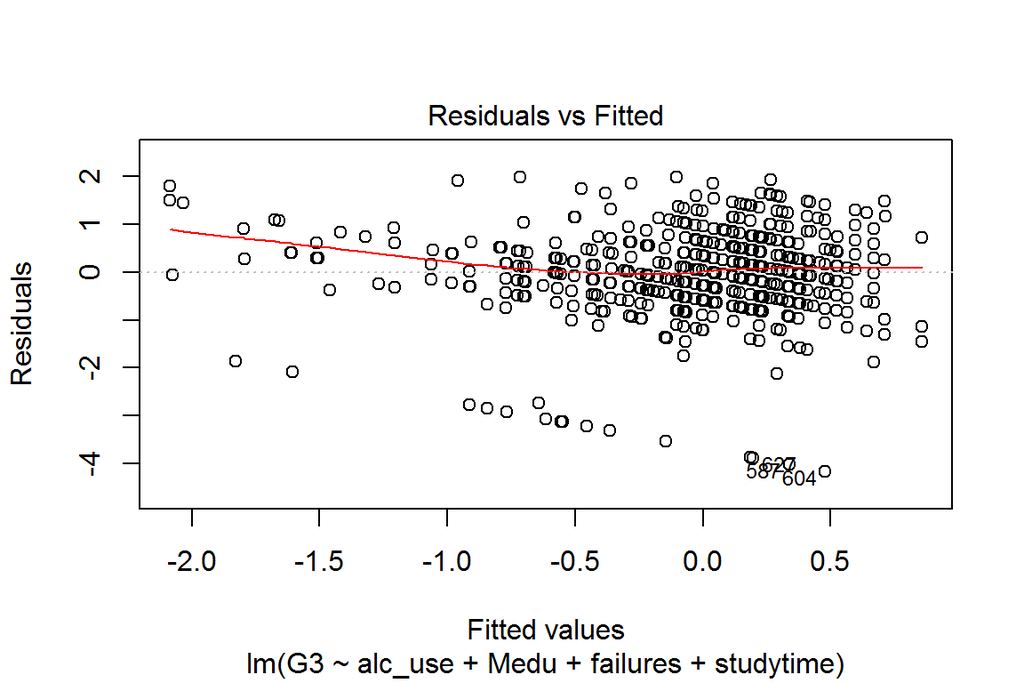

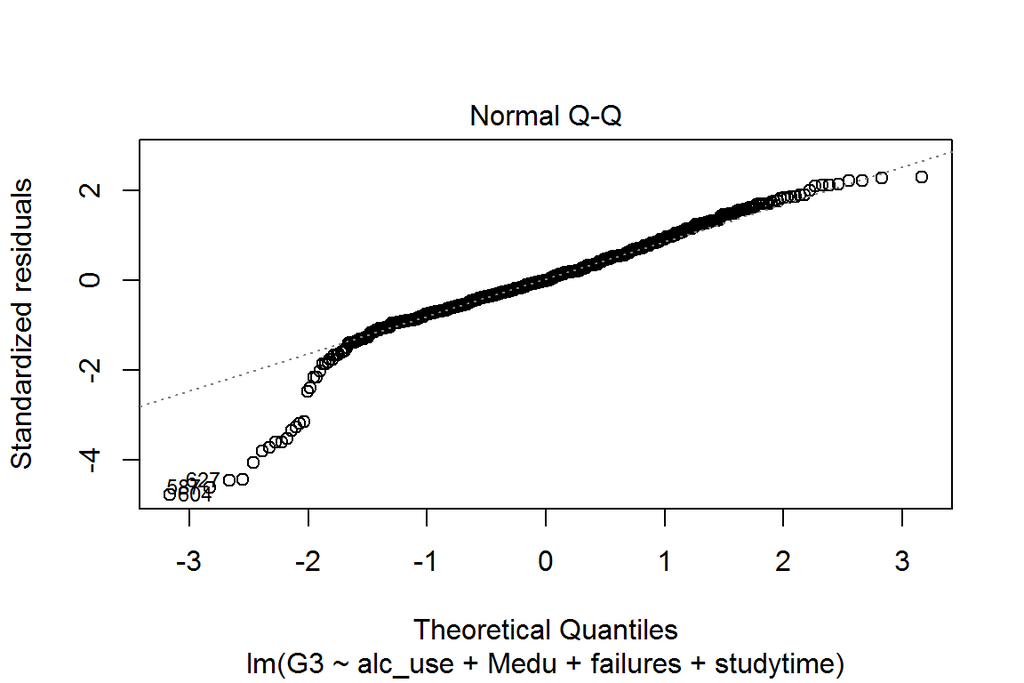

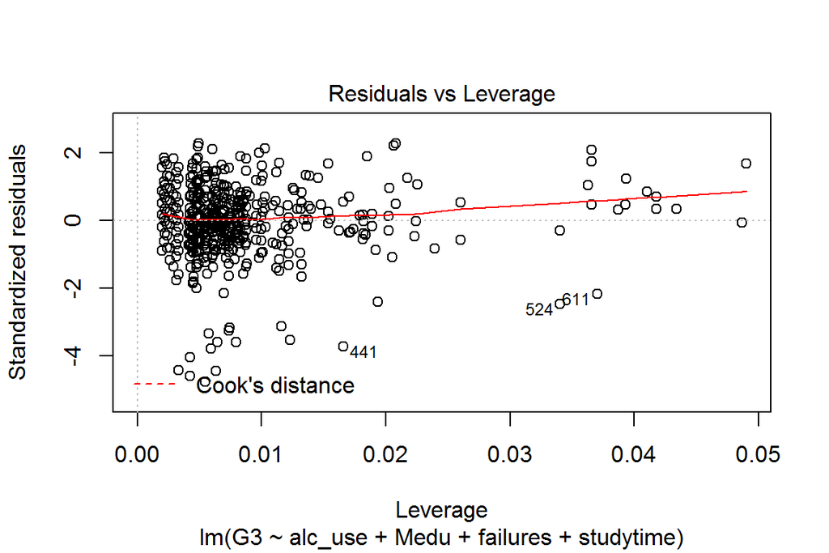

```r
plot(my_model, which=c(1,2,5))
```

Let’s check math data:

```r
my_model <- lm(formula = G3 ~ alc_use + absences + goout + Medu + Fedu + failures + studytime, data= mathData)

summary(my_model)
```

```
##
## Call:
## lm(formula = G3 ~ alc_use + absences + goout + Medu + Fedu +
##     failures + studytime, data = mathData)
##
## Residuals:
##      Min       1Q   Median       3Q      Max
## -2.72653 -0.45733  0.07031  0.63769  1.80898
##
## Coefficients:
##               Estimate Std. Error t value Pr(>|t|)
## (Intercept)  4.826e-16  4.644e-02   0.000   1.0000
## alc_use      4.447e-02  5.273e-02   0.843   0.3996
## absences     4.073e-02  4.740e-02   0.859   0.3908
## goout       -1.194e-01  5.101e-02  -2.341   0.0198 *
## Medu         1.565e-01  6.056e-02   2.583   0.0101 *
## Fedu        -1.941e-02  6.032e-02  -0.322   0.7479
## failures    -3.160e-01  4.972e-02  -6.356 5.82e-10 ***
## studytime    3.879e-02  4.881e-02   0.795   0.4273
## ---
## Signif. codes:  0 '***' 0.001 '**' 0.01 '*' 0.05 '.' 0.1 ' ' 1
##
## Residual standard error: 0.9229 on 387 degrees of freedom
## Multiple R-squared:  0.1634, Adjusted R-squared:  0.1482
## F-statistic:  10.8 on 7 and 387 DF,  p-value: 1.888e-12
```

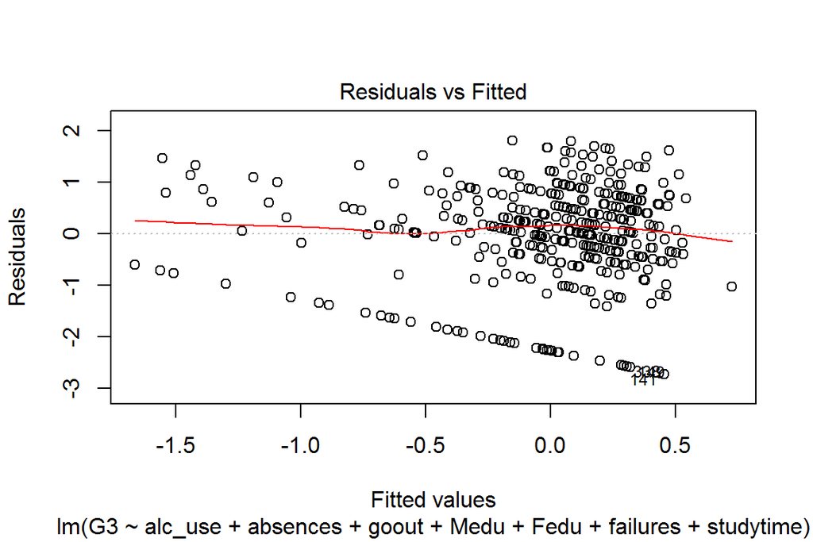

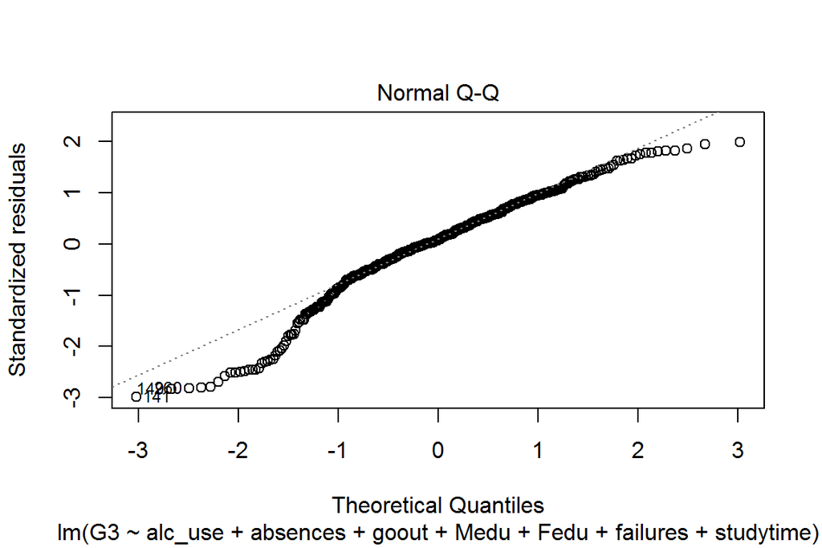

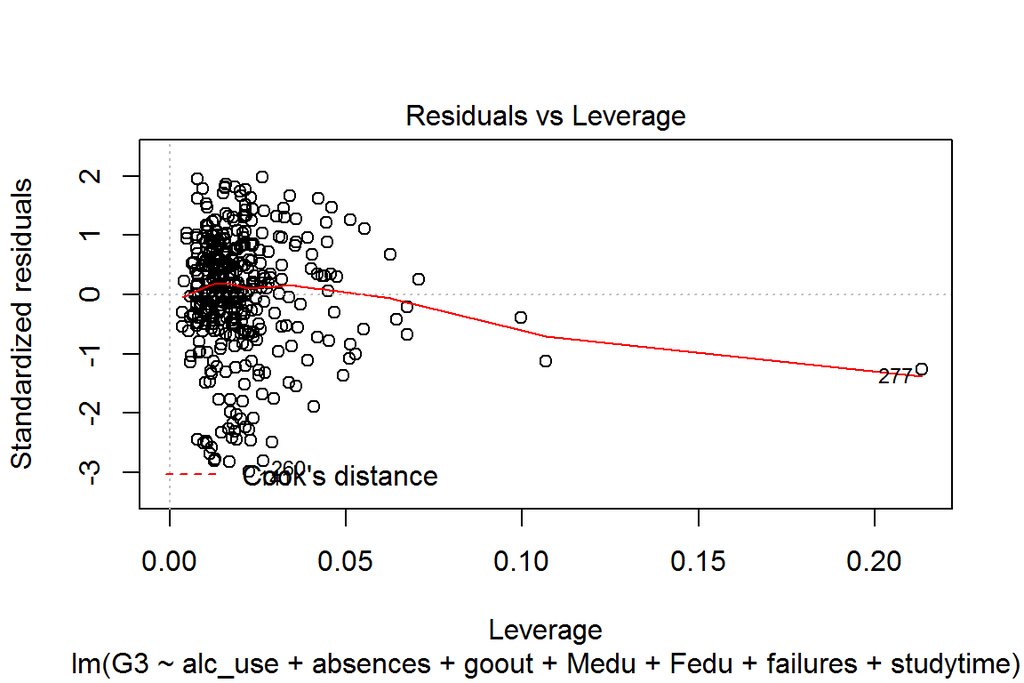

```r
plot(my_model, which=c(1,2,5))
```

It seems that when studyin maths study time doesn’t linearly correlate with final grade. Let’s fit model again with only significant values.

```r
my_model <- lm(formula = G3 ~ goout + Medu + failures, data= mathData)

summary(my_model)
```

```
##
## Call:
## lm(formula = G3 ~ goout + Medu + failures, data = mathData)
##
## Residuals:
##      Min       1Q   Median       3Q      Max
## -2.68797 -0.42839  0.07467  0.58611  1.84652
##
## Coefficients:
##               Estimate Std. Error t value Pr(>|t|)
## (Intercept)  3.763e-16  4.633e-02   0.000  1.00000
## goout       -1.035e-01  4.697e-02  -2.204  0.02809 *
## Medu         1.499e-01  4.797e-02   3.126  0.00191 **
## failures    -3.120e-01  4.824e-02  -6.468 2.97e-10 ***
## ---
## Signif. codes:  0 '***' 0.001 '**' 0.01 '*' 0.05 '.' 0.1 ' ' 1
##
## Residual standard error: 0.9207 on 391 degrees of freedom
## Multiple R-squared:  0.1588, Adjusted R-squared:  0.1523
## F-statistic:  24.6 on 3 and 391 DF,  p-value: 1.337e-14
```

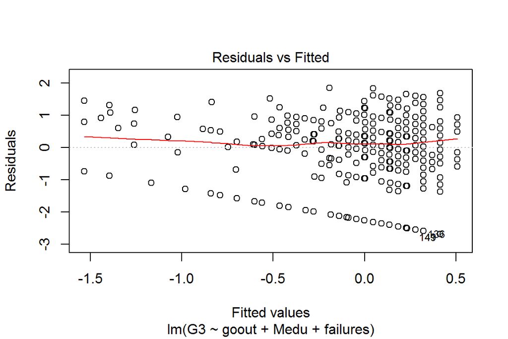

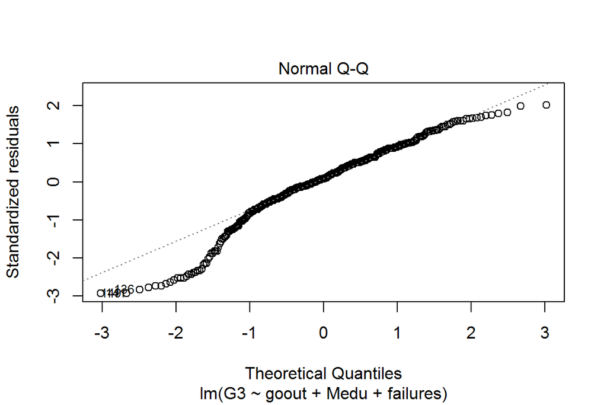

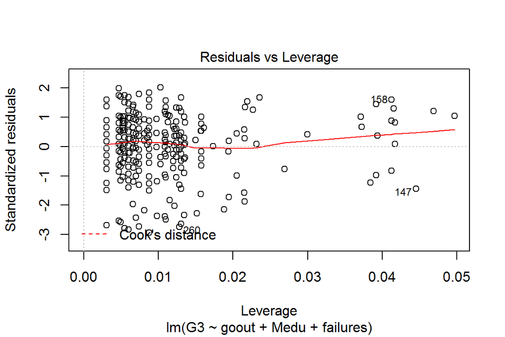

```r
plot(my_model, which=c(1,2,5))
```

It seems that also here mother’s education have positive impact on the final grade of the student.

## Model diagnostics

It seems that normal distribution asumption is incorrect based on residuals vs fitted plots. Residual vs Leverage looks quite good so no single value has large impact in the model. There seems to be problem with high and low values in the model based on Normal Q-Q plots.

# LDA

Finally we want to try LDA for categorized grade variables.

```r
library("MASS")
lda.fit <- lda(por_grade ~., data =porData)
lda.fit
```

```
## Call:
## lda(por_grade ~ ., data = porData)
##
## Prior probabilities of groups:
##      high       low  med_high   med_low
## 0.2018490 0.3035439 0.2234206 0.2711864
##
## Group means:
##           schoolMS      sexM         age  addressU famsizeLE3  PstatusT
## high     0.2366412 0.3282443  0.09717583 0.7633588  0.3282443 0.8702290
## low      0.5685279 0.4822335  0.24747893 0.5939086  0.2893401 0.8781726
## med_high 0.2206897 0.3448276 -0.18633403 0.8068966  0.2344828 0.8689655
## med_low  0.2897727 0.4431818 -0.19582357 0.6704545  0.3295455 0.8863636
##                 Medu        Fedu Mjobhealth Mjobother Mjobservices
## high      0.41434409  0.26949680 0.12977099 0.3435115    0.2366412
## low      -0.35069934 -0.33876257 0.06091371 0.4162437    0.1928934
## med_high  0.17249709  0.19148094 0.07586207 0.4344828    0.2068966
## med_low  -0.05797378  0.02083756 0.04545455 0.3863636    0.2102273
##          Mjobteacher Fjobhealth Fjobother Fjobservices Fjobteacher
## high      0.16793893 0.04580153 0.5419847    0.2595420  0.10687023
## low       0.04060914 0.03553299 0.5380711    0.3248731  0.01522843
## med_high  0.14482759 0.03448276 0.5586207    0.2551724  0.08275862
## med_low   0.11931818 0.02840909 0.6193182    0.2613636  0.03977273
##          reasonhome reasonother reasonreputation guardianmother
## high      0.2213740  0.06870229        0.3358779      0.7251908
## low       0.1675127  0.14213198        0.1370558      0.7360406
## med_high  0.3034483  0.07586207        0.2413793      0.7172414
## med_low   0.2443182  0.13636364        0.2102273      0.6306818
##          guardianother  traveltime   studytime   failures schoolsupyes
## high        0.03053435 -0.16805883  0.35966441 -0.3354135   0.01526718
## low         0.08629442  0.18301594 -0.29581741  0.6527888   0.11675127
## med_high    0.03448276 -0.13303969  0.17504260 -0.3391407   0.12413793
## med_low     0.08522727  0.02984274 -0.08080219 -0.2016183   0.14204545
##          famsupyes    paidyes activitiesyes nurseryyes higheryes
## high     0.6183206 0.03053435     0.5114504  0.8396947 1.0000000
## low      0.5837563 0.06091371     0.4416244  0.7918782 0.7360406
## med_high 0.6344828 0.05517241     0.5310345  0.8344828 0.9862069
## med_low  0.6250000 0.08522727     0.4772727  0.7613636 0.9147727
##          internetyes romanticyes      famrel    freetime       goout
## high       0.8549618   0.3740458  0.08852477 -0.07710140 -0.07285735
```

[output cut: 49 more lines]

```
## freetime         -0.013981387 -0.14486913  0.12081486
## goout             0.041311496  0.14046558  0.22626850
## Dalc              0.032998889  0.12253341  0.06428864
## Walc             -0.072535555  0.02264603 -0.02529027
## health            0.106321351  0.20137668  0.21414651
## absences          0.203469587 -0.13839688  0.15742041
## G1               -0.756210917 -0.38106502 -0.22291825
## G2               -0.442928329 -0.69571961  0.72790706
## G3               -1.117248156  0.63499487 -0.19637771
## alc_use          -0.032094421  0.07180536  0.01336076
## high_useTRUE      0.138218240 -0.52641635  0.22288884
##
## Proportion of trace:
##    LD1    LD2    LD3
## 0.9432 0.0460 0.0108
```

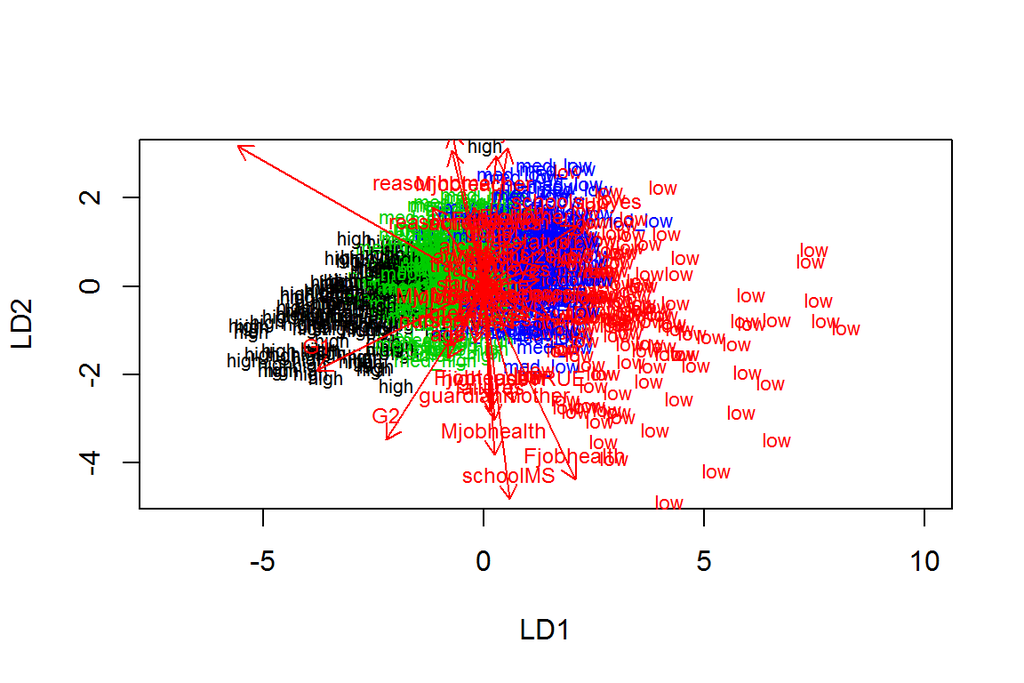

```r
# the function for lda biplot arrows
lda.arrows <- function(x, myscale = 1, arrow_heads = 0.1, color = "red", tex = 0.75, choices = c(1,2)){
  heads <- coef(x)
  arrows(x0 = 0, y0 = 0,
         x1 = myscale * heads[,choices[1]],
         y1 = myscale * heads[,choices[2]], col=color, length = arrow_heads)
  text(myscale * heads[,choices], labels = row.names(heads),
       cex = tex, col=color, pos=3)
}

# target classes as numeric
classes <- as.numeric(porData$por_grade)

# plot the lda results
plot(lda.fit, dimen = 2, col =classes, pch=classes)
lda.arrows(lda.fit, myscale = 5)
```